# Flexible Damage Functions

Author

James Rising, Sebastian Cadavid Sanchez, Climate Impact Lab

Published

April 9, 2026

## 0.1 Agriculture: Wheat Winter

Flexible damage function parameters for **Agriculture** (wheat_winter) at the Impact Region level.

**Change in winter wheat yields (log change in yields) under full adaptation**

$$D_{it} = (\alpha_i T_t + \beta_i T_t^2) \cdot Y_{it}^{\gamma}$$

where $\gamma$ is the income elasticity (fitted globally), $\alpha_i$ is the linear coefficient, and $\beta_i$ is the quadratic coefficient.

# 1 Global Estimation

## 1.1 Income Elasticity Estimation

The income elasticity $\gamma$ is estimated using a fixed-effects regression:

$$y_{it} = \gamma \cdot \log(Y_{it}) + \mu_{g(i,T)} + \nu_t + \varepsilon_{it}$$

where $\mu_{g(i,T)}$ are region-by-temperature-bin fixed effects and $\nu_t$ are year fixed effects.

Table 1: Income Elasticity (Gamma) Estimation Results

| Statistic | Value |
| --- | --- |
| Income elasticity ($\gamma$) | -0.0182 |
| Standard error | 9.75e-04 |
| 95% CI | [-0.0201, -0.0163] |
| R-squared | 0.9606 |
| Observations | 8,227,053 |
| Regions | 24,326 |
| Gamma quantiles | 19 |

# 2 Parameter Distributions

## 2.1 8-Panel Summary

Row 1: gamma, alpha, beta, rsqr1. Row 2: rho, zeta, eta, rsqr2.

```
Using median gamma: -0.018165, 24,326 rows (of 462,194 total)
```

[figure not shown]

Figure 1: Distribution of Regional Parameters

## 2.2 Projection Equation and Parameter Definitions

The estimated parameters are used to project damages via Monte Carlo sampling:

$$D_{it}^k = (\hat{\alpha}_{ik} T_t + \hat{\beta}_{ik} T_t^2) Y_{it}^{\hat{\gamma}_k} + \hat{\theta}_{ik} T_t Y_{it}^{\hat{\gamma}_k} + \hat{\phi}_{it}^k$$

where $k$ indexes the Monte Carlo draw. The parameters in each row of the output CSV control distinct components of this equation:

- **gamma**: income elasticity $\hat{\gamma}_k$, one of 19 quantile values drawn from $N(\hat{\gamma}, SE(\hat{\gamma}))$
- **alpha, beta**: linear and quadratic temperature coefficients; $\hat{\alpha}_{ik}$ and $\hat{\beta}_{ik}$ are drawn from the joint normal defined by the VCV below
- **sigma11, sigma12, sigma22**: variance-covariance matrix of $(\alpha, \beta)$, used for joint uncertainty sampling
- **rho**: correlation between regional and global polynomial residuals $\rho_i$, used to maintain spatial covariance across regions in Monte Carlo draws
- **zeta**: temperature-dependent error scale $\zeta_{ik}$; the run-specific error term $\hat{\theta}_{ik}$ is drawn from $N(0, \zeta_{ik})$
- **eta**: residual noise standard deviation $\eta_{ik}$; the annual noise $\hat{\phi}_{it}^k$ is drawn from $N(0, \eta_{ik})$
- **rsqr1, rsqr2**: polynomial fit quality and error model fit, respectively

## 2.3 Summary Statistics

Table 2: Regional Parameter Summary

| Parameter | Mean | Median | Std | Min | Max | N |
| --- | --- | --- | --- | --- | --- | --- |
| alpha | -0.07347 | -0.06526 | 0.133 | -0.5277 | 0.6849 | 24,326 |
| beta | -0.006134 | -0.003234 | 0.008539 | -0.09814 | 0 | 24,326 |
| rho | 0.1425 | 0.1548 | 0.1662 | -0.5245 | 0.5907 | 24,324 |
| zeta | 0.01454 | 0.01294 | 0.007839 | 0 | 0.1038 | 24,326 |
| eta | 0.026 | 0.02282 | 0.01531 | 0 | 0.1797 | 24,326 |
| rsqr1 | 0.7466 | 0.8984 | 0.2879 | 0 | 0.9949 | 24,326 |
| rsqr2 | 0.5712 | 0.5476 | 0.09496 | 0 | 0.9555 | 24,326 |

# 3 Spaghetti Curves

Regional damage function curves showing D(T) = αT + βT² for sampled regions.

(a) Regional Damage Functions

[interactive chart not shown]

Figure 2

# 4 Zero Crossings

The zero crossing (extremum) of the parabola occurs at $T^* = -\alpha / (2\beta)$.

Table 3: Zero Crossing Statistics

| Category | Count | Percentage |
| --- | --- | --- |
| β = 0 (no crossing) | 9264 | 38.1% |
| T > 20°C (beyond graph) | 32 | 0.1% |
| T < 0°C (negative crossing) | 8619 | 35.4% |
| Valid crossings (0-20°C) | 6411 | 26.4% |

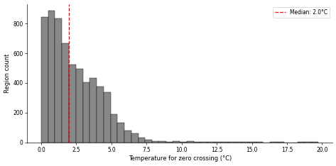

Figure 3: Distribution of Zero Crossing Temperatures

# 5 Slope Analysis

Maximum slope between 0 and 10°C: $\frac{dM}{dT} = \alpha + 2\beta T$

The maximum occurs at either T=0 or T=10 (endpoints of interval).

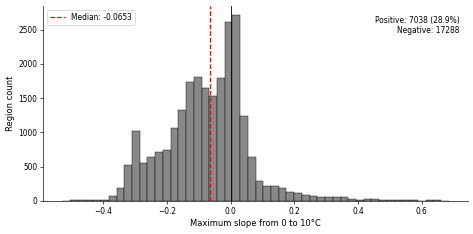

Figure 4: Distribution of Maximum Slopes (0-10°C)

*Convexity analysis omitted (beta constraint active).*

# 6 R-squared Analysis

## 6.1 Polynomial Fit Quality (rsqr1)

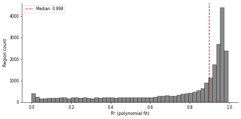

Figure 5: Regional Fit Quality (R-squared)

## 6.2 Error Model R-squared (rsqr2) Quantiles

Table 4: rsqr2 Quantiles

| 0% (Min) | 25% | 50% (Median) | 75% | 100% (Max) |
| --- | --- | --- | --- | --- |
| 0.0000 | 0.5096 | 0.5476 | 0.6107 | 0.9555 |

# 7 Modelled Variance

Modelled variance statistic: $1 - \frac{\sum_i \eta_i^2}{\sum_i D_i^2}$

Table 5: Modelled Variance Statistics

| Statistic | Value |
| --- | --- |
| Modelled variance | 0.9954 |
| Sum(η²) | 22.1450 |
| Sum(D²) at T=3.0°C | 4812.4314 |
| N regions | 24,326 |

# 8 Worst Offenders

The 2 worst-fitting regions by R-squared, with raw simulation data overlaid on the fitted polynomial curve.

Table 6: Worst-Fitting Regions (lowest R-squared)

| Region | alpha | beta | eta | R2 |
| --- | --- | --- | --- | --- |
| IND.17.217.761 | 0.0049 | -0.0015 | 0.0573 | 0.001 |
| PHL.66.1370 | 0.004 | -0.0005 | 0.037 | 0.0013 |

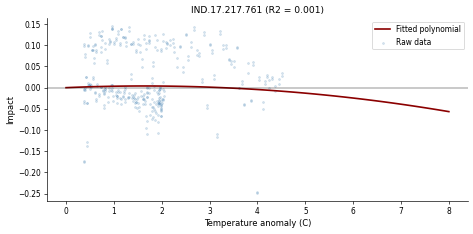

(a) Fitted polynomial with raw data for worst-fitting regions

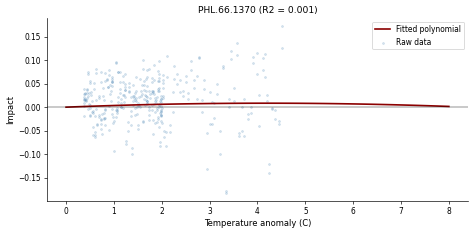

(b)

Figure 6

# 9 Regional Parameter Maps

Maps of key parameters at the **impact region level**. Red = negative (damage increases with T), Blue = positive.

## 9.1 Alpha (Linear Coefficient)

Alpha ($\alpha$) represents the linear sensitivity to temperature. Regions with negative alpha experience damage that increases with the first degree of warming.

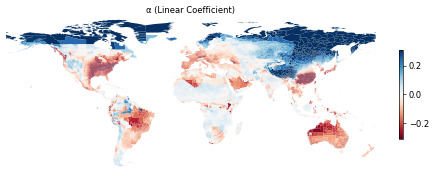

Figure 7: α (linear coefficient) at impact region level

## 9.2 Beta (Quadratic Coefficient)

Beta ($\beta$) represents the curvature of the damage function.

The concavity ($\beta \leq 0$) constraint is enforced for this sector, meaning optimal temperature exists, damages accelerate beyond it.

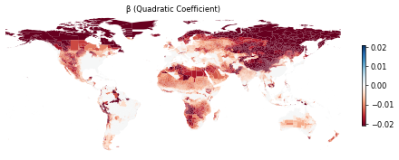

Figure 8: β (quadratic coefficient) at impact region level

## 9.3 R-squared (Fit Quality)

$R^2$ measures the polynomial fit quality. Higher values indicate that the quadratic form captures more of the variance in the data.

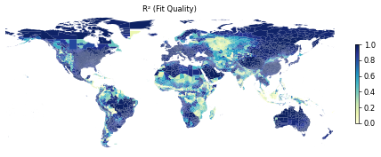

Figure 9: R² (stage 1 fit quality) at impact region level

# 10 F2: Flex vs Raw Comparison

Comparison of flexible damage function predictions against raw simulation means.

For each scenario (RCP × SSP × Model), we compute at the final year:

- **Flex predicted**: $(\alpha \cdot T + \beta \cdot T^2) \cdot Y^\gamma$
- **Raw actual**: The outcome variable (y) from the source data

**Year 2098**: 97,512 rows

**rcp45**

**SSP3**

**high**

**Correlation:** 0.9765 | **RMSE:** 0.048378 | **Sign agreement:** 91.5%

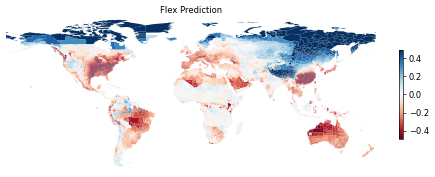

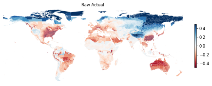

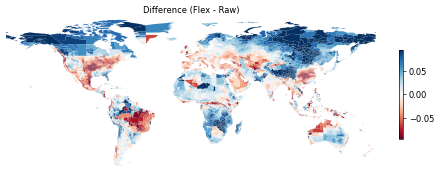

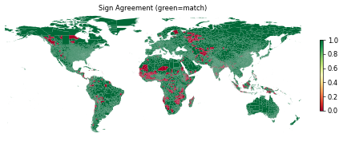

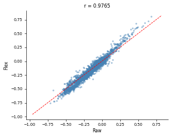

**Worst 10 Predictions:**

| Region | T (°C) | Raw | Flex | Residual |
| --- | --- | --- | --- | --- |
| COL.26.853 | 2.05 | -0.0067 | -0.3721 | -0.3654 |
| PER.11.99.Rcccacada0776bd05 | 2.05 | 0.1616 | 0.4421 | 0.2805 |
| TZA.1.2 | 2.05 | -0.1424 | -0.4173 | -0.275 |
| JAM.6 | 2.05 | 0.2009 | -0.0688 | -0.2697 |
| COL.21.727 | 2.05 | -0.1427 | -0.4082 | -0.2655 |
| COL.21.716 | 2.05 | -0.1977 | -0.4596 | -0.2619 |
| COL.21.747 | 2.05 | -0.116 | -0.376 | -0.26 |
| JAM.R6bcab63ca7cffd55 | 2.05 | 0.1776 | -0.0761 | -0.2537 |
| COL.12.449 | 2.05 | -0.2275 | -0.4672 | -0.2398 |
| VNM.2.16.149.1946 | 2.05 | -0.1763 | -0.4144 | -0.2381 |

**low**

**Correlation:** 0.9793 | **RMSE:** 0.043087 | **Sign agreement:** 93.4%

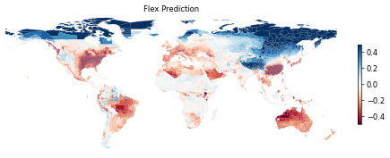

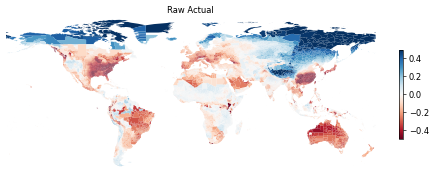

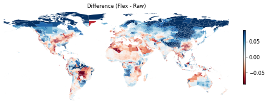

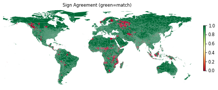

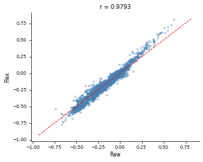

**Worst 10 Predictions:**

| Region | T (°C) | Raw | Flex | Residual |
| --- | --- | --- | --- | --- |
| COL.26.853 | 2.05 | -0.0395 | -0.3746 | -0.3351 |
| TZA.1.2 | 2.05 | -0.7234 | -0.4314 | 0.292 |
| JAM.6 | 2.05 | 0.2085 | -0.068 | -0.2765 |
| COL.12.447 | 2.05 | -0.022 | -0.2653 | -0.2433 |
| COL.21.727 | 2.05 | -0.1787 | -0.4109 | -0.2322 |
| VNM.6.55 | 2.05 | -0.4336 | -0.2089 | 0.2247 |
| JAM.R6bcab63ca7cffd55 | 2.05 | 0.1447 | -0.0752 | -0.2198 |
| CRI.4.44 | 2.05 | 0.2157 | -0.0012 | -0.2169 |
| HND.1 | 2.05 | 0.1973 | -0.0189 | -0.2162 |
| COL.21.716 | 2.05 | -0.2503 | -0.4627 | -0.2124 |

**rcp85**

**SSP3**

**high**

**Correlation:** 0.9901 | **RMSE:** 0.082952 | **Sign agreement:** 96.2%

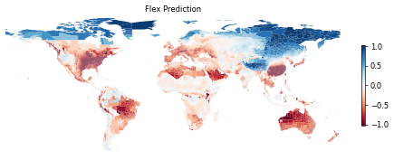

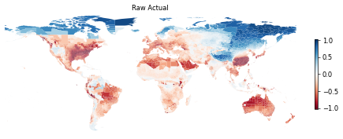

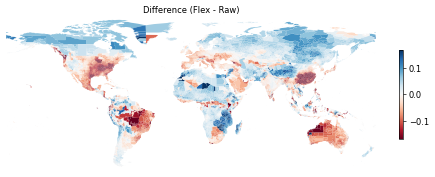

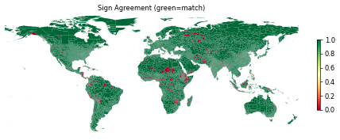

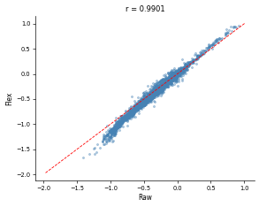

**Worst 10 Predictions:**

| Region | T (°C) | Raw | Flex | Residual |
| --- | --- | --- | --- | --- |
| ECU.11.103.485 | 4.51 | -1.3684 | -1.8173 | -0.4489 |
| PER.8.78.767 | 4.51 | -1.0013 | -1.4498 | -0.4485 |
| COL.21.R2796fe48858330ff | 4.51 | -1.5356 | -1.9699 | -0.4343 |
| ECU.18.169.820 | 4.51 | -1.1189 | -1.5516 | -0.4328 |
| COL.10.R2aa1e93b695593d5 | 4.51 | -1.4231 | -1.8331 | -0.41 |
| COL.17.631 | 4.51 | -1.398 | -1.8076 | -0.4096 |
| COL.29.999 | 4.51 | -1.3691 | -1.7749 | -0.4058 |
| COL.10.R01335b3dcd8ae64c | 4.51 | -1.2634 | -1.6675 | -0.4041 |
| IDN.26.334 | 4.51 | -0.5091 | -0.9119 | -0.4028 |
| COL.17.643 | 4.51 | -1.3805 | -1.7726 | -0.3921 |

**low**

**Correlation:** 0.9900 | **RMSE:** 0.077473 | **Sign agreement:** 96.2%

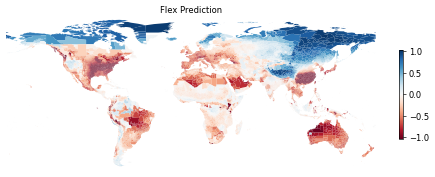

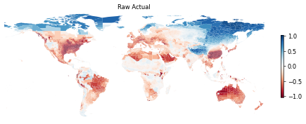

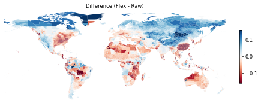

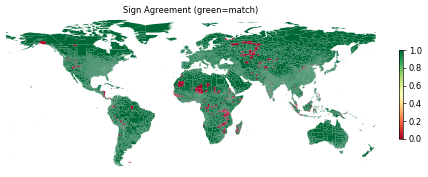

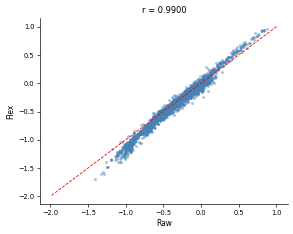

**Worst 10 Predictions:**

| Region | T (°C) | Raw | Flex | Residual |
| --- | --- | --- | --- | --- |
| COL.21.R2796fe48858330ff | 4.51 | -1.5391 | -1.983 | -0.4439 |
| COL.21.R562e67bd1bbaf7ec | 4.51 | -1.4531 | -1.8382 | -0.3851 |
| TZA.1.2 | 4.51 | -1.3839 | -1.0043 | 0.3797 |
| ECU.11.103.485 | 4.51 | -1.461 | -1.8354 | -0.3744 |
| COL.10.R2aa1e93b695593d5 | 4.51 | -1.4737 | -1.8453 | -0.3716 |
| COL.21.739 | 4.51 | -1.3841 | -1.7485 | -0.3644 |
| COL.17.643 | 4.51 | -1.4225 | -1.7845 | -0.362 |
| COL.29.999 | 4.51 | -1.4319 | -1.7867 | -0.3548 |
| KEN.3.19.94.391.1477 | 4.51 | -1.0629 | -1.4142 | -0.3512 |
| COL.17.631 | 4.51 | -1.4748 | -1.8197 | -0.3449 |

## 10.1 Scenario Summary

| RCP | SSP | Model | N | Corr | RMSE | Sign% |
| --- | --- | --- | --- | --- | --- | --- |
| rcp45 | SSP3 | high | 24,326 | 0.9765 | 0.048378 | 91.5% |
| rcp45 | SSP3 | low | 24,326 | 0.9793 | 0.043087 | 93.4% |
| rcp85 | SSP3 | high | 24,326 | 0.9901 | 0.082952 | 96.2% |
| rcp85 | SSP3 | low | 24,326 | 0.99 | 0.077473 | 96.2% |

# 11 Data Reference

## 11.1 File Locations

| Item | Path |
| --- | --- |
| Regional CSV | `/project/cil/gcp/flex_damage_funcs/parameters/agriculture__wheat_winter__regional_parameters.csv` |
| Global JSON | `/project/cil/gcp/flex_damage_funcs/parameters/agriculture__wheat_winter__global_results.json` |
| Metadata JSON | `/project/cil/gcp/flex_damage_funcs/parameters/agriculture__wheat_winter__metadata.json` |

## 11.2 Column Definitions

| Column | Description |
| --- | --- |
| `region` | Region identifier (hierarchical code, first 3 chars = country ISO3) |
| `gamma` | Income elasticity quantile value |
| `alpha` | Linear temperature coefficient |
| `beta` | Quadratic temperature coefficient |
| `sigma11` | Var(alpha) |
| `sigma12` | Cov(alpha, beta) |
| `sigma22` | Var(beta) |
| `rho` | Correlation with global residual process |
| `zeta` | Temperature-dependent heteroskedasticity |
| `eta` | Residual standard deviation |
| `rsqr1` | R-squared of polynomial fit |
| `rsqr2` | R-squared of error model |

*Report generated with FlexDamage v1.0.0*